# STA403-1 第一次作业

金科 201756010

### 第一周任务：P38 第8题

1. 用`read.csv()`函数将该数据读进R，将载入的数据命名为`college`

```r
college <- read.csv("ISLR_data/College.csv", header = T)
```

2. 用`fix()`函数观察数据

```r
rownames(college) = college[, 1]
fix(college)
```

`row.names`不是数据列，而是每个记录的名字

```r
college = college[, -1]
fix(college)
```

3. 汇总统计信息

```r
summary(college)
```

```
##  Private        Apps           Accept          Enroll       Top10perc
##  No :212   Min.   :   81   Min.   :   72   Min.   :  35   Min.   : 1.00
##  Yes:565   1st Qu.:  776   1st Qu.:  604   1st Qu.: 242   1st Qu.:15.00
##            Median : 1558   Median : 1110   Median : 434   Median :23.00
##            Mean   : 3002   Mean   : 2019   Mean   : 780   Mean   :27.56
##            3rd Qu.: 3624   3rd Qu.: 2424   3rd Qu.: 902   3rd Qu.:35.00
##            Max.   :48094   Max.   :26330   Max.   :6392   Max.   :96.00
##    Top25perc      F.Undergrad     P.Undergrad         Outstate
##  Min.   :  9.0   Min.   :  139   Min.   :    1.0   Min.   : 2340
##  1st Qu.: 41.0   1st Qu.:  992   1st Qu.:   95.0   1st Qu.: 7320
##  Median : 54.0   Median : 1707   Median :  353.0   Median : 9990
##  Mean   : 55.8   Mean   : 3700   Mean   :  855.3   Mean   :10441
##  3rd Qu.: 69.0   3rd Qu.: 4005   3rd Qu.:  967.0   3rd Qu.:12925
##  Max.   :100.0   Max.   :31643   Max.   :21836.0   Max.   :21700
##    Room.Board       Books           Personal         PhD
##  Min.   :1780   Min.   :  96.0   Min.   : 250   Min.   :  8.00
##  1st Qu.:3597   1st Qu.: 470.0   1st Qu.: 850   1st Qu.: 62.00
##  Median :4200   Median : 500.0   Median :1200   Median : 75.00
##  Mean   :4358   Mean   : 549.4   Mean   :1341   Mean   : 72.66
##  3rd Qu.:5050   3rd Qu.: 600.0   3rd Qu.:1700   3rd Qu.: 85.00
##  Max.   :8124   Max.   :2340.0   Max.   :6800   Max.   :103.00
##     Terminal       S.F.Ratio      perc.alumni        Expend
##  Min.   : 24.0   Min.   : 2.50   Min.   : 0.00   Min.   : 3186
##  1st Qu.: 71.0   1st Qu.:11.50   1st Qu.:13.00   1st Qu.: 6751
##  Median : 82.0   Median :13.60   Median :21.00   Median : 8377
##  Mean   : 79.7   Mean   :14.09   Mean   :22.74   Mean   : 9660
##  3rd Qu.: 92.0   3rd Qu.:16.50   3rd Qu.:31.00   3rd Qu.:10830
##  Max.   :100.0   Max.   :39.80   Max.   :64.00   Max.   :56233
##    Grad.Rate
##  Min.   : 10.00
##  1st Qu.: 53.00
##  Median : 65.00
##  Mean   : 65.46
##  3rd Qu.: 78.00
##  Max.   :118.00
```

对前十列变量生成散点图矩阵

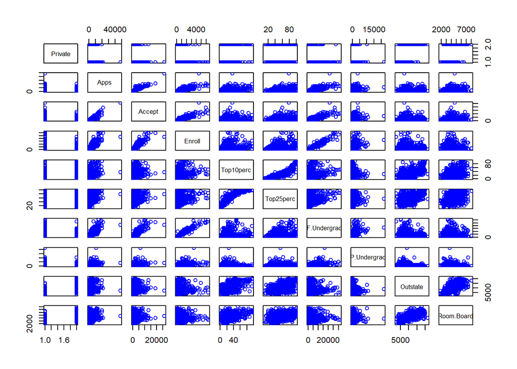

```r
pairs(college[, 1:10], col = "blue")
```

生成`Outstate`和`Private`变量的沿边箱线图

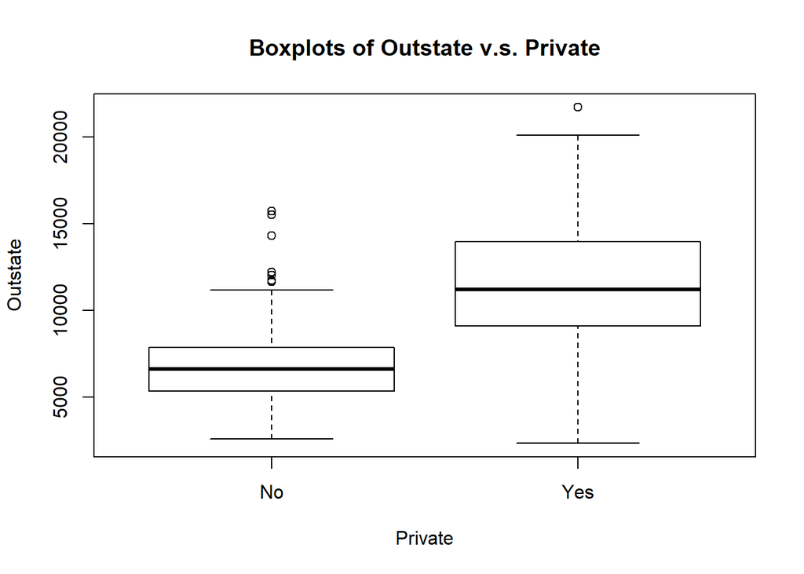

```r
plot(college$Private, college$Outstate,
     xlab = "Private", ylab = "Outstate",
     main = "Boxplots of Outstate v.s. Private")
```

排名在前10%顶尖高中的情况分组创建新变量

```r
Elite = rep("No", nrow(college))  # 初始化Elite变量
Elite[college$Top10perc > 50] = "Yes"  # 根据要求分组
Elite = as.factor(Elite)  # 转换为因子型
college = data.frame(college, Elite)  # 合并生成新的数据框
summary(Elite)
```

```
##  No Yes
## 699  78
```

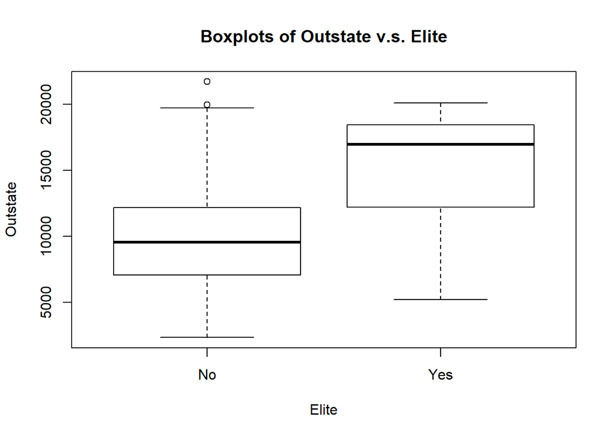

```r
plot(college$Elite, college$Outstate,
     xlab = "Elite", ylab = "Outstate",
     main = "Boxplots of Outstate v.s. Elite")
```

直方图

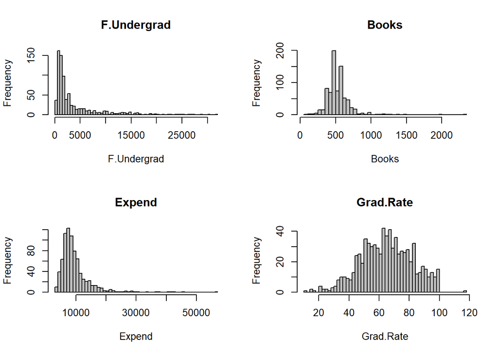

```r
attach(college)
par(mfrow = c(2,2))
hist(F.Undergrad, breaks = 50, col = "gray"，main = "F.Undergrad")
hist(Books, breaks = 50, col = "gray", main = "Books")
hist(Expend, breaks = 50, col = "gray", main = "Expend")
hist(Grad.Rate, breaks = 50, col = "gray", main = "Grad.Rate")
```

继续探索数据可以发现，**MIT**校园里有着最多的来自前10%顶尖高中的学生，**卡泽诺维亚学院**的毕业率最高。

```r
row.names(college)[which.max(Top10perc)]
```

```
## [1] "Massachusetts Institute of Technology"
```

```r
row.names(college)[which.max(Grad.Rate)]
```

```
## [1] "Cazenovia College"
```

### 第二周任务：P87 第15题

1. 简单回归

```r
library(MASS)
```

```r
lmp <- function(x) {
    lm <- lm(Boston$crim ~ x)
    f <- summary(lm)$fstatistic
    p <- pf(f[1],f[2],f[3], lower.tail=F)
    names(p) <- NULL
    return(p)
}

results <- apply(Boston[, -1], 2, lmp)
names(results) <- paste(names(Boston)[1],
                        names(Boston)[2:14],
                        sep = " ~ ")
results[results>=0.00001]
```

```
## crim ~ chas
##   0.2094345
```

由结果可以看出，除了`chas`以外，其他预测变量与人均犯罪率`crim`的模型都非常显著（$P-Value<0.00001$）。

2. 多元回归

```r
lm <- lm(crim ~., data = Boston)
summary(lm)
```

```
##
## Call:
## lm(formula = crim ~ ., data = Boston)
##
## Residuals:
##    Min     1Q Median     3Q    Max
## -9.924 -2.120 -0.353  1.019 75.051
##
## Coefficients:
##               Estimate Std. Error t value Pr(>|t|)
## (Intercept)  17.033228   7.234903   2.354 0.018949 *
## zn            0.044855   0.018734   2.394 0.017025 *
## indus        -0.063855   0.083407  -0.766 0.444294
## chas         -0.749134   1.180147  -0.635 0.525867
## nox         -10.313535   5.275536  -1.955 0.051152 .
## rm            0.430131   0.612830   0.702 0.483089
## age           0.001452   0.017925   0.081 0.935488
## dis          -0.987176   0.281817  -3.503 0.000502 ***
## rad           0.588209   0.088049   6.680 6.46e-11 ***
## tax          -0.003780   0.005156  -0.733 0.463793
## ptratio      -0.271081   0.186450  -1.454 0.146611
## black        -0.007538   0.003673  -2.052 0.040702 *
## lstat         0.126211   0.075725   1.667 0.096208 .
## medv         -0.198887   0.060516  -3.287 0.001087 **
## ---
## Signif. codes:  0 '***' 0.001 '**' 0.01 '*' 0.05 '.' 0.1 ' ' 1
##
## Residual standard error: 6.439 on 492 degrees of freedom
## Multiple R-squared:  0.454,  Adjusted R-squared:  0.4396
## F-statistic: 31.47 on 13 and 492 DF,  p-value: < 2.2e-16
```

如上结果所示，在0.05的显著性水平下，变量`zn`、`dis`、`rad`、`black`、`medv`可以拒绝零假设$H_0: \beta_j = 0$。

```r
# 简单回归系数
coef_1 <- apply(Boston[, -1], 2,
                function(x){coefficients(lm(Boston$crim~x))[2]})
# 多元回归系数
coef_2 <- coefficients(lm)
coef_2 <- as.data.frame(coef_2)[-1,]

# 合并数据框
coef <- data.frame(coef_1, coef_2)
```

绘制散点图，比较回归系数

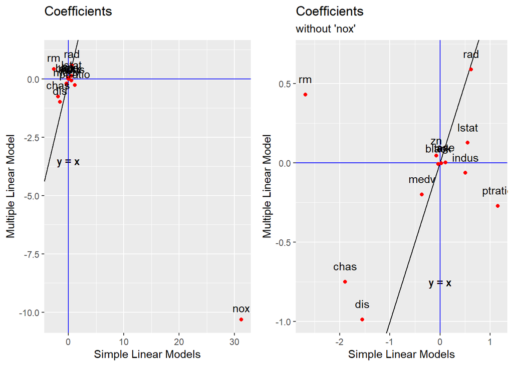

```r
library(ggplot2)

p1 <- ggplot(coef, aes(x = coef_1, y = coef_2)) +
    geom_abline(intercept = 0, slope = 1) +
    geom_text(aes(0, -3.5, label = "y = x")) +
    geom_vline(xintercept = 0, color = "blue") +
    geom_hline(yintercept = 0, color = "blue") +
    geom_point(color = "red") +
    geom_text(aes(y = coef_2 + .5, label = names(Boston)[-1])) +
    labs(x = "Simple Linear Models",
         y = "Multiple Linear Model",
         title = "Coefficients",
         subtitle = "")

p2 <- ggplot(coef[-4,], aes(x = coef_1, y = coef_2)) +
    geom_abline(intercept = 0, slope = 1) +
    geom_text(aes(0, -.75, label = "y = x")) +
    geom_vline(xintercept = 0, color = "blue") +
    geom_hline(yintercept = 0, color = "blue") +
    geom_point(color = "red") +
    geom_text(aes(y = coef_2 + .1, label = names(Boston)[c(-1,-5)])) +
    labs(x = "Simple Linear Models",
         y = "Multiple Linear Model",
         title = "Coefficients",
         subtitle =  "without 'nox'")

# 合并显示
cowplot::plot_grid(p1, p2)
```

左图可以看出，变量`nox`在两种模型中的回归系数相距甚远；如右图，变量`rm`、`indus`和`ptratio`位于二、四象限，说明在两个模型中它们的回归系数正负符号不同，拟合情况相差较大。

4. 对每个预测变量**分别**进行多项式回归

```r
coefp <- function (x) {
    lm <- lm(Boston$crim ~ x+I(x^2)+I(x^3))
    cf <- summary(lm)$coefficients
    return(cf[-1,4])
}
res_ploy <- apply(Boston[, -1], 2, coefp)
res_ploy_dataframe <- as.data.frame(res_ploy)
t(res_ploy_dataframe)
```

```
##                    x       I(x^2)       I(x^3)
## zn      2.612296e-03 9.375050e-02 2.295386e-01
## indus   5.297064e-05 3.420187e-10 1.196405e-12
## chas    2.094345e-01 2.094345e-01 2.094345e-01
## nox     2.758372e-13 6.811300e-15 6.961110e-16
## rm      2.117564e-01 3.641094e-01 5.085751e-01
## age     1.426608e-01 4.737733e-02 6.679915e-03
## dis     6.374792e-18 4.941214e-12 1.088832e-08
## rad     6.234175e-01 6.130099e-01 4.823138e-01
## tax     1.097075e-01 1.374682e-01 2.438507e-01
## ptratio 3.028663e-03 4.119552e-03 6.300514e-03
## black   1.385871e-01 4.741751e-01 5.436172e-01
## lstat   3.345300e-01 6.458736e-02 1.298906e-01
## medv    2.637707e-28 3.260523e-18 1.046510e-12
```